# Analiza danych w języku python

# Wprowadzenie

Celem poniższego projektu jest analiza oferty turystycznej agencji Rainbow Tour na lato 2023. Do uzyskania danych ze strony agencji posłużono się web-scrapingiem, czyli techniką polegającą na automatycznym pobieraniu tekstu z kodu html stron internetowych. Do teg celu wykorzystano w głównej mierze dwie biblioteki pythona: BeautifulSoup oraz Selenium. Dane na temat wycieczek zostały pobrane za pomocą odwołań do zawartości odpowiendich tagów html, z których zbudowana jest strona. Uzyskane informacje przekształcono do formy tabeli.

W drugiej części projektu dokonano analizy pozyskanych danych. Podjęto próbe odpowiedzi na takie pytania jak:

- do jakich krajów i miast najczęściej organizowane są wycieczki?
- jakie wycieczki są oceniane najlepiej przez turystów?
- jakie są najpopularniejsze formy wyżywienia na wczasach?
- od jakich czynników zależą ceny wycieczek?

W ostatniej części projektu dokonano próby budowy modelu, który byłby w stanie przewidywać ceny wycieczek na podstawie ich pozostałych cech.

# 1. Pozyskanie danych

## 1.1. Import pakietów

```python
# !pip install selenium
# !pip install webdriver-manager
from selenium import webdriver
from selenium.webdriver.chrome.service import Service
from webdriver_manager.chrome import ChromeDriverManager
from selenium.webdriver.common.by import By
from selenium.webdriver.common.action_chains import ActionChains
from selenium.webdriver.common.keys import Keys
from selenium.common.exceptions import NoSuchElementException
from bs4 import BeautifulSoup
import requests
import time
import re
import numpy as np
import pandas as pd
from collections import Counter
import matplotlib.pyplot as plt
import seaborn as sns
# !pip install wordcloud
from wordcloud import WordCloud, STOPWORDS
from sklearn.model_selection import train_test_split
from sklearn.ensemble import RandomForestRegressor
from sklearn.tree import plot_tree
from sklearn.inspection import permutation_importance
from sklearn.metrics import mean_squared_error, mean_absolute_percentage_error, mean_absolute_error
from sklearn.metrics import r2_score
```

## 1.2. Web-scraping

Ponieważ licba wyświetlanych ofert na stronie Rainbow jest ograniczona do 10, podjęto próbę automatycznego rozszerzenia listy ofert przy pomocy przycisku "Pokaż więcej". Do tego celu wykorzystano bibliotekę selenium.

Za pomocą poniższego kodu możliwe jest uruchomienie okna przeglądarki i rozszerzenie listy ofert poprzez kliknięcie na przycisk "Pokaż więcej" zdefiniowaną liczbę razy. Przycisk "Pokaż więcej" na stronie Rainbow znika ze strony po naciśnięciu i pozostaje niewidoczny do momentu trzykrotnego załadowania kolejnych ofert i przewinięcia strony na sam dół listy. Poniższy kod bieżę pod uwagę to zachowanie i po naciśnięciu przycisku "Pokaż więcej" kilkakrotnie przewija stronę na samą górę oraz na sam dół, aby pozwolić na załadowanie kolejnych ofert. Następnie czeka określoną liczbę sekund na ponowne pojawienie się przycisku.

### Otwarcie przeglądarki

```python
# open web browser
driver = webdriver.Chrome(service=Service(ChromeDriverManager().install()))
driver.session_id
```

```
'14470b08f0f8a07be7d78285dbd0be2b'
```

```python
# open page of Rainbow Tour
PAGE_URL = 'https://r.pl/szukaj?sezon=lato-2023'
driver.get(PAGE_URL)
driver.maximize_window()
```

```python
# accept cookies
btn = driver.find_element(By.XPATH, "//*[contains(text(), 'Akceptuj wszystkie')]")
btn.click()
```

### Rozszerzenie listy ofert

```python
# expand list of offerts MAX_ITER_I times
SHOW_MORE_CLASS_NAME = 'szukaj-bloczki__load-more-button'
MAX_ITER_I = 50
MAX_ITER_J = 5
SLEEP_TIME = 5

for i in range(MAX_ITER_I):
    try:
        # click on "Show more" button
        expand_bar = driver.find_element(By.CLASS_NAME, SHOW_MORE_CLASS_NAME)
        expand_bar.click()
        for j in range(MAX_ITER_J):
            # Scroll page up and down to let offerts load
            actions = ActionChains(driver)
            actions.send_keys(Keys.PAGE_UP).perform()
            actions.send_keys(Keys.PAGE_DOWN).perform()
            time.sleep(SLEEP_TIME)
        print(f"List expanded {i+1} times")
    except Exception as ex:
        print(f"Exception during expanding list: {ex}")
        break
```

```
List expanded 1 times
List expanded 2 times
List expanded 3 times
List expanded 4 times
List expanded 5 times
List expanded 6 times
List expanded 7 times
List expanded 8 times
List expanded 9 times
List expanded 10 times
List expanded 11 times
List expanded 12 times
List expanded 13 times
List expanded 14 times
List expanded 15 times
List expanded 16 times
List expanded 17 times
List expanded 18 times
List expanded 19 times
List expanded 20 times
List expanded 21 times
List expanded 22 times
List expanded 23 times
List expanded 24 times
List expanded 25 times
List expanded 26 times
List expanded 27 times
List expanded 28 times
List expanded 29 times
List expanded 30 times
List expanded 31 times
List expanded 32 times
List expanded 33 times
List expanded 34 times
List expanded 35 times
List expanded 36 times
List expanded 37 times
List expanded 38 times
List expanded 39 times
List expanded 40 times
List expanded 41 times
List expanded 42 times
List expanded 43 times
List expanded 44 times
List expanded 45 times
List expanded 46 times
List expanded 47 times
List expanded 48 times
List expanded 49 times
List expanded 50 times
```

### Zapisanie zawartości kodu html do pliku

```python
# retrieve html content
html_content = driver.page_source

# save html to text file
with open('page_html_content.txt', 'w', encoding="utf-8") as file:
    file.write(html_content)
```

```python
# close the browser window
driver.close()
```

```python
with open('../Projekt/page_html_content.txt', 'r', encoding="utf-8") as file:
    r_html = file.read().rstrip()

# parse html content with bs4
soup = BeautifulSoup(r_html, 'html.parser')
```

```python
len(r_html)
```

```
34412976
```

### Identyfikacja bloków z ofertami

```python
# find all blocks with offert
OFFER_BLOCK_CLASS_NAME = 'n-bloczek szukaj-bloczki__element'
offer_blocks = soup.find_all("a", {"class": OFFER_BLOCK_CLASS_NAME})
```

```python
len(offer_blocks)
```

```
2098
```

### Zbieranie informacji o wycieczkach

```python
# class names of proper html tags
TITLE = re.compile('.*r-bloczek-naglowek__tytul.*')
LOCATION = re.compile('.*r-bloczek-lokalizacja.*')
STARS = 'r-gwiazdki r-gwiazdki--medium'
RATING = re.compile('.*r-bloczek-ocena r-bloczek__ocena.*')
DATE = 'r-bloczek-wlasciwosc__dni'
AIRPORT = 'r-bloczek-wlasciwosc'
FOOD = 'r-bloczek-wlasciwosc'
PRICE = re.compile('.*r-bloczek-cena__aktualna.*')
OLD_PRICE = 'r-bloczek-cena__przed-obnizka'

def get_offer_df(offer_block_html):
    """
    Function retrieves information about single offer from html and saves them to pandas data frame.
    """
    offer = offer_block_html
    # offer title
    title = offer.find("span", {"class": TITLE}).get_text().strip()
    # trip destination
    loc = offer.find("span", {"class": LOCATION}).get_text().strip()
    loc = loc.replace('\u205f•\u205f', ' ')
    loc = loc.replace('\u205f•', ' ')
    loc_component = loc.split(":")
    if len(loc_component) > 1:
        country, city = loc_component[:2]
    else:
        country = loc_component[0]
        city = np.nan
    country = country.replace("Wypoczynek ", "")
    country = country.replace("Objazd + wypoczynek ", "")
    country = country.replace("Objazd ", "")
    # stars
    offer_stars = offer.find("div", {"class": STARS})
    if offer_stars is not None:
        offer_stars = float(offer_stars['data-rating'])
    else:
        offer_stars = np.nan

    # rating
    offer_rating = offer.find("span", {"class": RATING})
    if offer_rating is not None:
        offer_rating = offer_rating.get_text().strip()
        offer_rating = offer_rating.replace('\xa0', '')
        ratings_no = int(re.search('\(\d+\.*', offer_rating).group().replace('(', ''))
        rating = float(re.search('\d+\.\d+', offer_rating).group().replace(' ', ''))
    else:
        rating = np.nan
        ratings_no = 0
    # date
    offer_date = offer.find("div", {"class": DATE}).find_all('span')[0].get_text().strip() # '05.05.2023 (8 dni)'
    duration = int(re.search('\d+ dni', offer_date).group().replace(' dni', ''))
    date = re.search('[\d\.]+ \(', offer_date).group().replace(' (', '')
    # airport
    offer_airport = offer.find_all("div", {"class": AIRPORT})[1].find_all('span')[0].get_text().strip()
    # food
    offer_food = offer.find_all("div", {"class": AIRPORT})
    if len(offer_food) > 2:
        offer_food = offer_food[2].find_all('span')[0].get_text().strip()
    else:
        offer_food = np.nan
    # price
    offer_price = offer.find("span", {"class": PRICE}).get_text().strip()
    price = float(re.search('\d+\ \d+', offer_price).group().replace(' ', ''))
    # old price
    offer_price_before = offer.find("span", {"class": PRICE_BEFORE})
    if offer_price_before is not None:
        offer_price_before = offer_price_before.get_text().strip()
        offer_price_before = float(re.search('\d+\ \d+', offer_price_before).group().replace(' ', ''))
    else:
        offer_price_before = np.nan

    trips_dict = {
        "title": [title],
        "location": [loc],
        "country": [country],
        "city": [city],
        "stars": [offer_stars],
        "rating": [rating],
        "ratings_no": [ratings_no],
        "date": [date],
        "duration": [duration],
        "airport": [offer_airport],
        "food": [offer_food],
        "price": [price],
        "old_price": [offer_price_before]
    }
    return pd.DataFrame(trips_dict)
```

```python
# create data frame where each row corresponds with info about single offer
trips_df = [get_offer_df(offer) for offer in offer_blocks]
trips_df = pd.concat(trips_df, ignore_index=True)
```

```python
# save data to .csv
trips_df.to_csv("rainbow_summer_2023.csv", index=False)
```

# 2. Analiza ofert Rainbow Tour na lato 2023

W drugiej części projektu dokonano analizy opisowej danych dotyczących wycieczek na lato 2023 organizowanych przez biuro podróży Rainbow Tour. W ramach analizy dokonano interpretacji statystyk opisowych oraz zwizualizowane na wykresach. Dodatkowo podjęto próbę interpretacji pozyskanych danych i dokonano bardziej szczegółowej analizy cen wycieczek z wykorzystaniem drzewa regresyjnego.

## 2.1. Opis zbioru danych

Analizowany zbiór danych składa się z 2098 rekordów i 13 kolumn. Każdy wiersz opisuje pojedynczą ofertę wycieczkową, którą można zakupić na stronie biura podróży Rainbow Tour. Wszystkie wyjazdy zaplanowano na okres od maja do grudnia 2023 r.

Kolumny obecne w opisanym zbiorze danych zawierają następujące informacje o wycieczkach organizowanych w sezonie letnim 2023 roku:

- **Title** - tytuł oferty,
- **Location** - cel podróży (kraj i miasto),
- **Country** - kraj docelowy,
- **City** - miasto docelowe,
- **Stars** - liczba gwiazdek przypisanych do wyjazdu przez agencję,
- **Rating** - średnia ocena osób, które uczestniczyły w wycieczce,
- **Ratings number** - ile razy wycieczka została oceniona,
- **Date** - data rozpoczęcia wycieczki,
- **Duration** - czas trwania podróży w dniach,
- **Airport** - miasto, w którym znajduje się lotnisko,
- **Food** - rodzaj wyżywienia zapewnianego podczas wyjazdu,
- **Price** - aktualna cena oferty,
- **Old price** - poprzednia cena oferty (jeśli wycieczka jest na promocji)

W przypadku niektórych zmiennych, takich jak „City”, „Stars”, „Rating” i „Old price” występują braki danych, co jest ma swoje logiczne uzasadnienie. Podróże z brakującymi wartościami w kolumnie „City” dotyczą objazdu po wielu krajach. Kolumny „Stars” i „Rating” mogą być puste, ponieważ niektóre oferty mogły do tej pory nie zostać ocenione przez agencję lub żadną osobę. Brak wartości w kolumnie „Old price” oznacza, że wycieczka ma nadal swoją cenę podstawową, która do tej pory nie została obniżona.

```python
trips_df = pd.read_csv("../Projekt/rainbow_offerts_2023.csv")
```

```python
trips_df.head(5)
```

|  | title | location | country | city | stars | rating | ratings_no | date | duration | airport | food | price | old_price |
| --- | --- | --- | --- | --- | --- | --- | --- | --- | --- | --- | --- | --- | --- |
| 0 | Paras Sun | Wypoczynek Grecja: Rodos | Grecja | Rodos | 2.0 | 4.5 | 188 | 12.05.2023 | 8 | Warszawa Chopin | Śniadania | 1500.0 | NaN |
| 1 | Anaxos Bay | Wypoczynek Grecja: Lesbos | Grecja | Lesbos | 2.0 | 5.0 | 11 | 30.08.2023 | 8 | Katowice | Bez wyżywienia | 1558.0 | NaN |
| 2 | Elena Studios | Wypoczynek Grecja: Lesbos | Grecja | Lesbos | 2.0 | 4.9 | 25 | 30.08.2023 | 8 | Katowice | Bez wyżywienia | 1635.0 | NaN |
| 3 | Studia Maria | Wypoczynek Grecja: Kokkino Nero | Grecja | Kokkino Nero | 2.5 | 5.2 | 71 | 31.05.2023 | 8 | Wrocław | Bez wyżywienia | 1766.0 | NaN |
| 4 | Apartamenty Omiś | Wypoczynek Chorwacja: Kastelanska Riwiera - Ma... | Chorwacja | Kastelanska Riwiera - Makarska Riwiera | 2.5 | 3.7 | 12 | 22.06.2023 | 8 | Katowice | Bez wyżywienia | 1779.0 | NaN |

```python
trips_df.shape
```

```
(2098, 13)
```

```python
trips_df.info()
```

```
<class 'pandas.core.frame.DataFrame'>
RangeIndex: 2098 entries, 0 to 2097
Data columns (total 13 columns):
 #   Column      Non-Null Count  Dtype
---  ------      --------------  -----
 0   title       2098 non-null   object
 1   location    2098 non-null   object
 2   country     2097 non-null   object
 3   city        1869 non-null   object
 4   stars       1621 non-null   float64
 5   rating      1511 non-null   float64
 6   ratings_no  2098 non-null   int64
 7   date        2098 non-null   object
 8   duration    2098 non-null   int64
 9   airport     2098 non-null   object
 10  food        2083 non-null   object
 11  price       2098 non-null   float64
 12  old_price   787 non-null    float64
dtypes: float64(4), int64(2), object(7)
memory usage: 213.2+ KB
```

W poniższej tabeli przedstawiono statsytyki opisowe zmiennych ilościowych obecnych w analizowanym zbiorze danych. Z tabeli można odczytać między innymi następujące informacje:

- średnia i jednocześnie najczęstsza ocena, jaką agencja przypisuje wycieczkom to 4 na 5 gwiazdek. Wycieczka oceniana najsłabiej ma 2 gwiazdki. Ponad 25% wycieczek ma maksymalną ocenę od agencji - 5 na 5 gwiazdek. Ponad 400 wycieczek nie posiada ratingu od agencji.
  - średnia ocen użytkowników to 5 na 6 przy odchyleniu standardowym 0.5. Najniższa średnia ocen występująca w zbiorze to 2.8. Ponad 500 wycieczek nie zostało ocenionych przez żadnego użytkownika.
- wycieczki są oceniane przez średnio 40 użytkowników, przy czym rozkład liczby ocen jest mocno prawostronnie skośny, o czym świadczy mediana równa 7. Istnieje zatem wiele wycieczek, posiadających małą liczbę ocen użytkowników oraz pewna ilość o nieprzeciętnie dużej liczbie ocen.
- znaczna większość wyjazdów jes organizowana na okres 8 dni. Najdłuższa wycieczka w zbiorze trwa 22 dni, zaś najkrtósza to jednodniowa oferta.
- średnia cena pojedynczej wycieczki to około 5.4 tys. przy czym rozkład cen jest prawostronnie skośny - występują wycieczki o cenie dużo większej niż cena przeciętnej oferty.
- blisko 800 wyjazdów w ofercie agencji zostało przecenionych. Rozkład cen wycieczek przed obniżką charakteryzują wartości około 2 tys. wyższe niż rozkład aktualnych cen. Najdroższa cena wycieczki przed obniżką wynosiła 32 tys.

```python
trips_df.describe().T
```

|  | count | mean | std | min | 25% | 50% | 75% | max |
| --- | --- | --- | --- | --- | --- | --- | --- | --- |
| stars | 1621.0 | 4.194016 | 0.752458 | 2.0 | 4.0 | 4.0 | 5.0 | 5.0 |
| rating | 1511.0 | 5.203574 | 0.513023 | 2.8 | 4.9 | 5.3 | 5.5 | 6.0 |
| ratings_no | 2098.0 | 42.864156 | 94.447141 | 0.0 | 0.0 | 7.0 | 41.0 | 1153.0 |
| duration | 2098.0 | 8.137274 | 1.984016 | 1.0 | 8.0 | 8.0 | 8.0 | 22.0 |
| price | 2098.0 | 5403.183985 | 3341.820485 | 1500.0 | 3030.0 | 4174.0 | 7178.0 | 31845.0 |
| old_price | 787.0 | 7511.074968 | 3942.275887 | 2447.0 | 4298.0 | 7383.0 | 9109.0 | 32345.0 |

### **Jak oceniane są wycieczki?**

Poniższe wykresy przedstawiają rozkłady ocen użytkowników. Wykres po lewej to podstawowy histogram ocen. W przypadku wykresu po prawej, średnią ocen każdej wycieczki przemnożono przez ilość ocen. Porównując wykresy można zauważyć, że znaczna część ofert posiadających bardzo niskie lub wysokie oceny, została w rzeczywistości oceniona przez niewielką liczbę użytkowników. Im więcej uzytkowników oceniło daną wycieczkę, tym bardziej jej średnia ocena zmieża ku średniej wszystkich ocen - około 5.25.

```python
ratings = []
for _, row in trips_df.iterrows():
    if row['ratings_no']:
        r = [row['rating']] * row['ratings_no']
        ratings.extend(r)
```

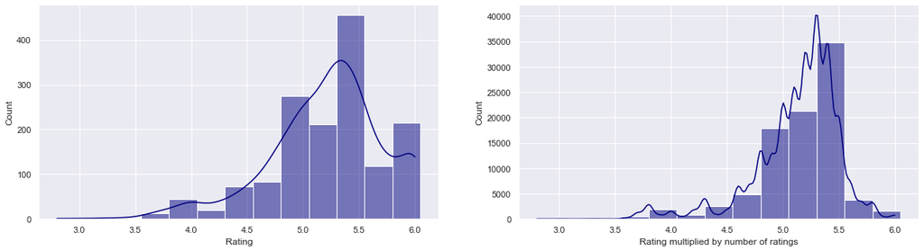

```python
fig, axs = plt.subplots(1, 2, figsize=(20, 5))
sns.histplot(data=pd.Series(ratings), color='navy', binwidth=0.25, kde=True, ax=axs[1])
axs[1].set(xlabel="Rating multiplied by number of ratings")
sns.histplot(data=trips_df["rating"], color='navy', binwidth=0.25, kde=True, ax=axs[0])
axs[0].set(xlabel="Rating")
plt.show()
```

### **Jaka jest długość wyjazdów?**

Większość wycieczek w ofercie agencji Rainbow Tour trwa 8 dni. Nieliczne wyjazdy trwają 9, 5 lub 4 dni. Pozostałe długości trwania wyjazdów pomiędzy 1 a 22 dni są bardzo rzadkie. Po sprawdzeniu jakie wycieczki trwają powyżej 16 dni, okazuje się, że są to wycieczki objazdowe, najczęściej obejmujące podróż do kilku krajów. Są one także drogie - kosztują w większości powyżej 30 tys.

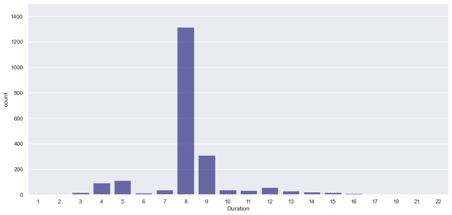

```python
trips_df["discount"] = np.where(trips_df["old_price"].isna(), "No", "Yes")
plt.figure(figsize=(15, 7))
ax = sns.countplot(data=trips_df, x='duration', color='navy', alpha=.6)
ax.set_ylim([0, 1500])
ax.set(xlabel="Duration")
plt.show()
```

```python
trips_df[trips_df["duration"] > 16].sort_values("duration")
```

|  | title | location | country | city | stars | rating | ratings_no | date | duration | airport | food | price | old_price |
| --- | --- | --- | --- | --- | --- | --- | --- | --- | --- | --- | --- | --- | --- |
| 2040 | Od Amharów do Hamerów | Objazd Etiopia: Addis Abeba | Etiopia | Addis Abeba | NaN | 5.6 | 44 | 06.11.2023 | 17 | Warszawa Chopin | Śniadania i obiadokolacje | 13443.0 | 14043.0 |
| 2096 | Po drugiej stronie Ziemi | Objazd Australia i Nowa Zelandia | Australia i Nowa Zelandia | NaN | NaN | 5.1 | 77 | 27.10.2023 | 19 | Warszawa Chopin | Śniadania | 31598.0 | 32048.0 |
| 2095 | Pocztówka z końca Świata | Objazd Singapur, Australia, Nowa Zelandia, Fidżi | Singapur, Australia, Nowa Zelandia, Fidżi | NaN | NaN | 4.9 | 10 | 31.10.2023 | 21 | Warszawa Chopin | Śniadania | 31546.0 | 31996.0 |
| 2097 | Od A do Z | Objazd Australia, Zjednoczone Emiraty Arabskie... | Australia, Zjednoczone Emiraty Arabskie, Nowa ... | NaN | NaN | 4.9 | 20 | 26.10.2023 | 22 | Warszawa Chopin | Śniadania | 31845.0 | 32345.0 |

### **Do których krajów i miast organizowane jest najwięcej wycieczek?**

Poniżej zostały wyświetlone kraje oraz miasta, do których organizowane jest odpowiendio ponad 60 oraz 40 wycieczek spośród oferty agencji.

```python
words_counter = dict(Counter(trips_df['country']))
popular_countires = [country for country in words_counter.keys() if words_counter[country] > 60]

BOLD = '\033[1m'
END = '\033[0m'

for country in popular_countires:
    print("- " + BOLD + country + END, end="\n")
```

```
- Grecja
- Bułgaria
- Turcja
- Tunezja
- Egipt
- Włochy
- Hiszpania
- Kenia
- Tajlandia
- Kuba
```

```python
words_counter_city = dict(Counter(trips_df['city']))
popular_cities = [city for city in words_counter_city.keys() if words_counter_city[city] > 40]
popular_cities.remove(np.nan)

for city in popular_cities:
    print("- " + BOLD + str(city) + END, end="\n")
```

```
-  Słoneczny Brzeg
-  Riwiera Turecka
-  Hurghada
-  Sycylia
-  Teneryfa
-  Varadero
```

### **Jakie są charakterystyki najczęściej odwiedzanych krajów?**

Spośród krajów, do których wycieczki organizowane są najczęściej, przeciętnie najtańszą opcją jest Tunezja, a także Turcja i Bułgaria. Najdroższe ceny wycieczek charakteryzują zaś kraje położone daleko od Europy - Kubę oraz Tajlandię. Najwyższe oceny agencja przyznaje wycieczką do Egiptu oraz do Turci. Z kolei klienci Rainbow Tour najwyższe opinie wystawiają wycieczkom do Tajlandii oraz Kenii.

```python
popular_countires_df = trips_df[trips_df['country'].isin(popular_countires)]
popular_countires_df[['country', 'stars', 'rating', 'price']].groupby(['country']).median().T
```

| country | Bułgaria | Egipt | Grecja | Hiszpania | Kenia | Kuba | Tajlandia | Tunezja | Turcja | Włochy |
| --- | --- | --- | --- | --- | --- | --- | --- | --- | --- | --- |
| stars | 4.0 | 5.0 | 4.0 | 4.0 | 4.0 | 4.0 | 4.0 | 4.0 | 5.0 | 4.0 |
| rating | 5.0 | 5.3 | 5.2 | 5.3 | 5.4 | 5.0 | 5.5 | 5.3 | 5.4 | 5.0 |
| price | 2926.0 | 3170.0 | 3174.0 | 4127.0 | 6666.0 | 8057.0 | 8007.0 | 2639.0 | 2998.0 | 4357.5 |

### **Jakie słowa występują najczęściej w nazwach wycieczek?**

Na poniższym wykresie przedstawiono słowa (z wykluczeniem stop words) występujące najczęsciej w tytułach wycieczek.

```python
# import english stopwords
import nltk
nltk.download('stopwords')
from nltk.corpus import stopwords
```

```python
# read polish stopwords from text file
polish_sw = []
with open('polish_stopwords.txt','r') as file:
    for line in file:
        for word in line.split():
            polish_sw.append(word)
# extract every word from each title and convert to lower case
trip_titles_words = [z.lower() for y in [x.split() for x in trips_df["title"] if isinstance(x, str)] for z in y]
# get words' counts
words_counter = dict(Counter(trip_titles_words))
popular_words = sorted(words_counter, key=words_counter.get, reverse=True)
# exclude stopwords from list
popular_words = [w for w in popular_words if w not in stopwords.words("english")]
popular_words = [w for w in popular_words if w not in polish_sw]
popular_words = [w for w in popular_words if (len(w) > 2) and (w.isalpha())]
```

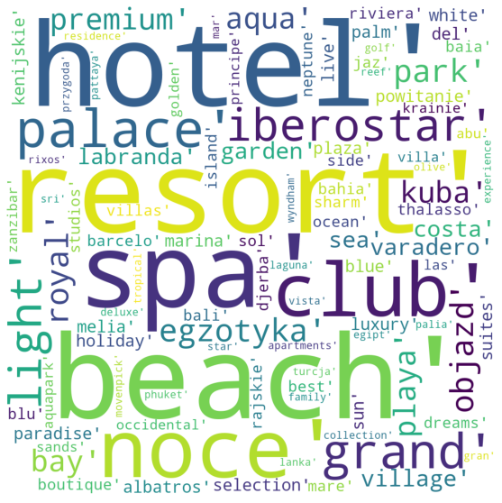

```python
def plot_popular_words(words_list, max_words=100, width=1000, height=1000):
    word_string = str(popular_words)
    wordcloud = WordCloud(stopwords=STOPWORDS, background_color='white',
                          max_words=max_words, width=width, height=height,
                         ).generate(word_string)
    plt.clf()
    plt.imshow(wordcloud)
    plt.axis('off')
    plt.show()

plt.figure(figsize=(20, 10))
plot_popular_words(popular_words)
```

### **Z jakich lotnisk Rainbow Tour najczęściej organzizuje wycieczki?**

Wśród lotnisk, z których najczęsciej rozpoczynają się wycieczki najczęściej występują lotnisko w Katowicach oraz Warszawa Chopin. Znaczne mniejsza część wycieczek swój początek ma na lotnisku we Wrocławiu oraz w Poznaniu. Kraków i Gdańsk występują bardzo rzadko.

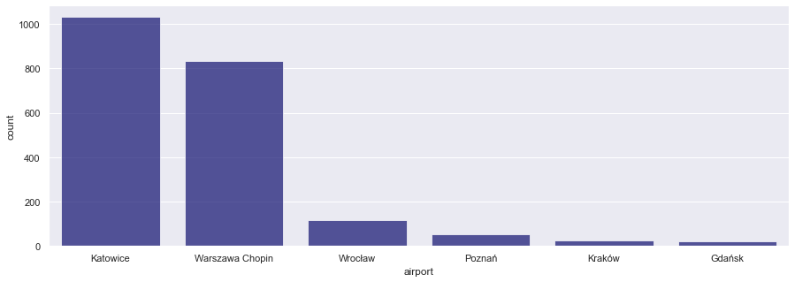

```python
plt.figure(figsize=(15, 5))
popular_airports = [airport for airport in trips_df['airport'].value_counts().index if (trips_df['airport'].value_counts()[airport] > 10)]
popular_airports_df = trips_df[trips_df['airport'].isin(popular_airports)]
sns.countplot(data=popular_airports_df, x='airport', color='navy', alpha=.7, order=popular_airports_df['airport'].value_counts().index)
plt.show()
```

#### **Jaki jest najczęstszy rodzaj wyżywienia?**

Wśród najpopularniejszych rodzajów wyżywienia występuje All iclusive, same śniadania lub śniadania oraz obiadokolacje. Niektóre wycieczki posidają pakiet wyżywienia ultra all inclusive lub nawet dedykowany programowi danej oferty.

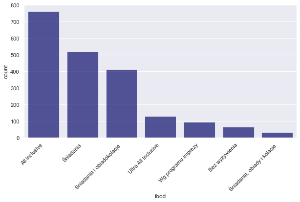

```python
plt.figure(figsize=(10, 5))
popular_foods = [food for food in trips_df['food'].value_counts().index if (trips_df['food'].value_counts()[food] > 20)]
popular_food_df = trips_df[trips_df['food'].isin(popular_foods)]
sns.countplot(data=popular_food_df, x='food', color='navy', alpha=.7, order=popular_food_df['food'].value_counts().index)
plt.xticks(rotation=45, ha='right')
plt.show()
```

### **W jakich miesiącach odbywają się wycieczki?**

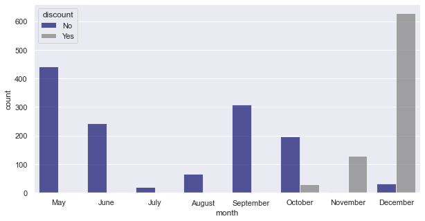

```python
trips_df['month'] = pd.to_datetime(trips_df['date'], format="%d.%m.%Y").dt.strftime('%B')
plt.figure(figsize=(10, 5))
mnth_order = ['May', 'June', 'July', 'August', 'September', 'October', 'November', 'December']
sns.countplot(data=trips_df, x='month', hue="discount", palette=['navy', 'grey'],
              alpha=.7, order=mnth_order)
plt.show()
```

# 3. Predykcja cen wycieczek

W kolejnej części projektu dokonano próby budowy modelu przewidującego ceny wycieczek na podstawie pozostałych zmiennych. Przed budową modelu, dokonano analizy zależności rozkładu cen od własności wycieczek w celu wybrania tych, które mogą istotnie wypływać na zmienna objaśnianą. Po usunięciu zmiennych nieistotnych, zmienne kategoryczne zamieniono na zmienne binarne. Następnie podzielono dane na zbiór uczący oraz testowy, uzupełniono braki danych i wytrenowano model drzewa regresyjnego.

## 3.1. Cena a pozostałe cechy wycieczki

### **Ilość gwiazdek**

Poniższy wykres wskazuje, że im wyższą liczbę gwizdek od agencji posiada dana wycieczka, tym większa prawdopodobnie będzie jej cena.

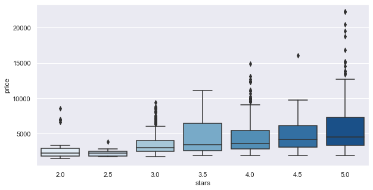

```python
plt.figure(figsize=(10, 5))
sns.boxplot(data=trips_df, y='price', x="stars", palette="Blues")
plt.show()
```

### **Kraj**

Poniższy wykres pokazuje rozkład cen wycieczek do najbardziej popularnych krajów. Zdecydowanie najdroższą opcją spośród możliwych destynacji jest Kenia, Tajlandia oraz Kuba. Z kolei najtańsze są oferty do Bułgarii oraz Tunezji.

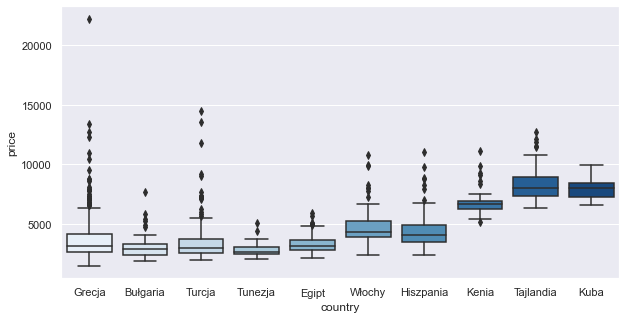

```python
plt.figure(figsize=(10, 5))
sns.boxplot(data=popular_countires_df, y='price', x='country', palette='Blues')
plt.show()
```

### **Rodzaj wyżywienia**

Nie dziwi fakt, że oferty, w ramach których nie jest zapewniane wyżywienie, są najtańsze. Największy przedział cenowy dotyczy wycieczek w ramach których agencja zapewnia tylko śniadanie. Co zaskakujące ich cena jest średnio wyższa niż wycieczek z wyżywieniem All inclusive. Najdroższą opcją są wycieczki z wyżywieniem dostosowanym do programu imprezy.

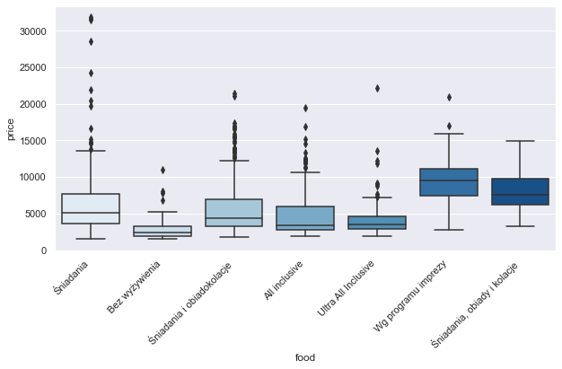

```python
plt.figure(figsize=(10, 5))
sns.boxplot(data=popular_food_df, y='price', x='food', palette='Blues')
plt.xticks(rotation=45, ha='right')
plt.show()
```

### **Lotnisko**

Średnia cena wycieczek organizowanych z Warszawy jest większa niż dla wycieczek z lotnisk w pozostałych miastach.

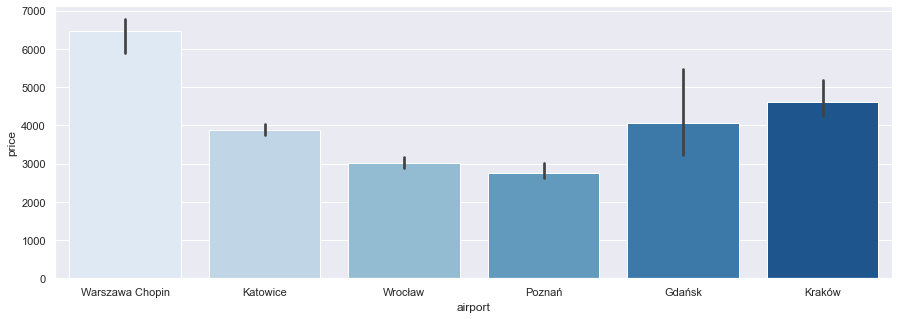

```python
plt.figure(figsize=(15, 5))
sns.barplot(data=popular_airports_df, y='price', x="airport", palette='Blues', estimator='median')
plt.show()
```

### **Miesiąc**

Wycieczki organizowane w okresie wakacyjnym a także z dużym okresem wyprzedzenia (listopad, grudzień) są średnio drozsze niż wyjazdy w maju, czerwcu czy wrześniu.

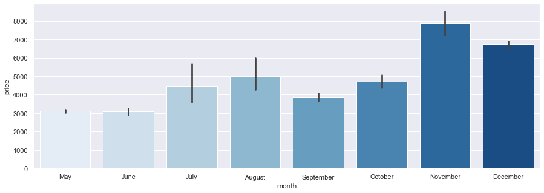

```python
plt.figure(figsize=(15, 5))
sns.barplot(data=trips_df, y='price', x="month", palette='Blues', estimator='median', order=mnth_order)
plt.show()
```

### **Zniżka**

Poniższy wykres wskazuje, że droższe wycieczki otrzymują z reguły większą zniżkę.

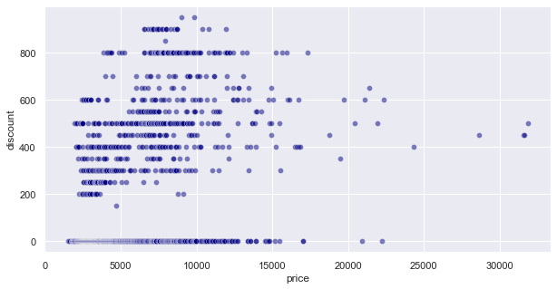

```python
trips_df['discount'] = np.where(trips_df['old_price'].isna(), 0, trips_df['old_price'] - trips_df['price'])
plt.figure(figsize=(10, 5))
sns.scatterplot(data=trips_df, x='price', y='discount', color='navy', alpha=.5)
plt.show()
```

### **Ocena**

Trudno wywnioskować dokładną zależność między ceną wycieczek a ocena użytkowników, jednak z wykresu wynika, że oferty powyżej 5 tys. znacznie rzadziej charakteryzują się średnią ocen poniżej 4.5 w stosunku do ofert poniżej 5 tys.

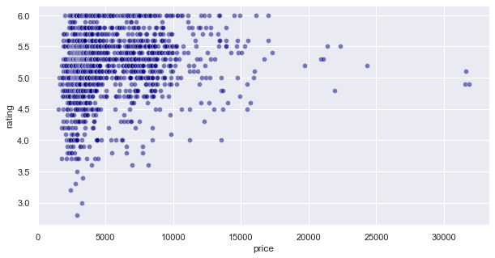

```python
plt.figure(figsize=(10, 5))
sns.scatterplot(data=trips_df, x='price', y='rating', color='navy', alpha=.5)
plt.show()
```

### **Ilość ocen**

Ilość ocen wycieczek spada wraz z wysokością ceny. Można to wyjąsnić faktem, iż im droższa wycieczka, tym mniej osób może sobie na nią pozwolić.

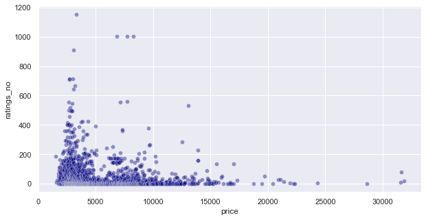

```python
plt.figure(figsize=(10, 5))
sns.scatterplot(data=trips_df, x='price', y='ratings_no', color='navy', alpha=.4)
plt.show()
```

## 3.2. Preprocessing danych

Jako zmienne wybrane do finalnego modelu zdecydowano się wybrać: Kraj, Ilość gwiazdek, Ocena użytkowników, Ilość ocen użytkowników, Lotnisko, Długość trwania, Rodzaj wyżywienia, Wielkość zniżki. Zmienną objaśnianą będzie cena wycieczki.

```python
selected_columns = ['country', 'stars', 'rating', 'ratings_no', 'airport', 'duration', 'food', 'discount', 'price']
df = trips_df[selected_columns].copy()
```

### Usunięcie outlierów

Ponieważ niektóre wycieczki mają ponadprzeciętnie wysoką cenę, zdecydowano się wykluczyć je ze zbioru danych. Usunięto oferty przekraczające 0.99 kwantyl rozkładu.

```python
np.quantile(df["price"], .99)
```

```
16619.270000000022
```

```python
df = df[df["price"] < np.quantile(df["price"], .99)]
df.shape
```

```
(2077, 9)
```

### Zamiana zmiennych kategorycznych na zmienne binarne

```python
df['greece'] = np.where(~df['country'].isin(['Grecja']), 0, 1)
df['thailand'] = np.where(~df['country'].isin(['Tajlandia']), 0, 1)
df.drop(columns=['country'], inplace=True)
```

```python
df['food'] = np.where(df['food'].isin(['Bez wyżywienia']), 0, 1)
```

```python
df['duration'] = np.where(df['duration'] < 7, 0, 1)
```

```python
df['airport'] = np.where(df['airport'].isin(['Warszawa Chopin']), 0, 1)
```

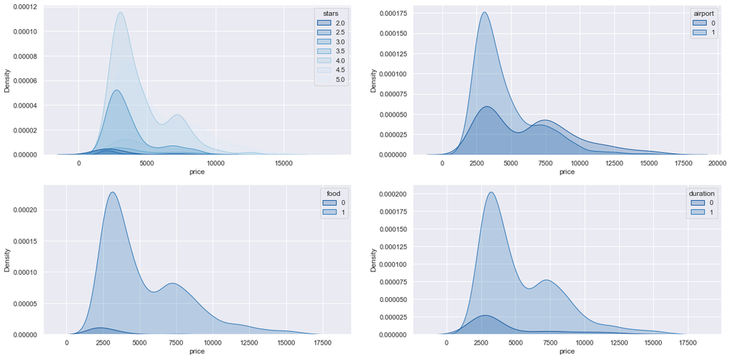

```python
cols = ['food', 'duration']
nplots = len(cols)
fig, axs = plt.subplots(2, 2, figsize=(20, 10))
p = list(reversed(sns.color_palette("Blues", 7)))
sns.kdeplot(data=df, x="price", hue="stars", ax=axs[0, 0], fill=True, palette=p)
sns.kdeplot(data=df, x="price", hue="airport", ax=axs[0, 1], fill=True, palette=p[:2])
for i, col in enumerate(cols):
    sns.kdeplot(data=df, x="price", hue=col, ax=axs[1, i], fill=True, palette=p[:2])
plt.show()
```

```python
df.head()
```

|  | stars | rating | ratings_no | airport | duration | food | discount | price | greece | thailand |
| --- | --- | --- | --- | --- | --- | --- | --- | --- | --- | --- |
| 0 | 2.0 | 4.5 | 188 | 0 | 1 | 1 | 0.0 | 1500.0 | 1 | 0 |
| 1 | 2.0 | 5.0 | 11 | 1 | 1 | 0 | 0.0 | 1558.0 | 1 | 0 |
| 2 | 2.0 | 4.9 | 25 | 1 | 1 | 0 | 0.0 | 1635.0 | 1 | 0 |
| 3 | 2.5 | 5.2 | 71 | 1 | 1 | 0 | 0.0 | 1766.0 | 1 | 0 |
| 4 | 2.5 | 3.7 | 12 | 1 | 1 | 0 | 0.0 | 1779.0 | 0 | 0 |

## 3.3. Podział na zbiór uczący i testowy

W kolejnym kroku dokonano podziału zbioru danych na zbiór uczący i testowy w stosunku 8:2. Oznacza to, że 80% danych posłuży do zbudowania modelu, zaś 20% do sprawdzenia jego dokładności. Następnie oba zbiory zweryfikowano pod kątem podstawowych statystyk opisowych, aby upewnić się, że oba zbiory nie różnią się od siebie znacząco.

```python
X_cols = list(df.columns)
X_cols.remove('price')
seed = 50
X, y = df.loc[:, X_cols], df.loc[:, 'price']
X_train, X_test, y_train, y_test = train_test_split(X, y, test_size=0.2, random_state=seed)
```

```python
X_train.describe().T
```

|  | count | mean | std | min | 25% | 50% | 75% | max |
| --- | --- | --- | --- | --- | --- | --- | --- | --- |
| stars | 1291.0 | 4.188613 | 0.749585 | 2.0 | 4.0 | 4.0 | 5.0 | 5.0 |
| rating | 1211.0 | 5.193972 | 0.516941 | 2.8 | 4.9 | 5.3 | 5.5 | 6.0 |
| ratings_no | 1661.0 | 44.123420 | 99.759342 | 0.0 | 0.0 | 8.0 | 41.0 | 1153.0 |
| airport | 1661.0 | 0.614690 | 0.486815 | 0.0 | 0.0 | 1.0 | 1.0 | 1.0 |
| duration | 1661.0 | 0.878989 | 0.326239 | 0.0 | 1.0 | 1.0 | 1.0 | 1.0 |
| food | 1661.0 | 0.970500 | 0.169255 | 0.0 | 1.0 | 1.0 | 1.0 | 1.0 |
| discount | 1661.0 | 183.293197 | 267.658169 | 0.0 | 0.0 | 0.0 | 400.0 | 950.0 |
| greece | 1661.0 | 0.133654 | 0.340383 | 0.0 | 0.0 | 0.0 | 0.0 | 1.0 |
| thailand | 1661.0 | 0.037929 | 0.191082 | 0.0 | 0.0 | 0.0 | 0.0 | 1.0 |

```python
X_test.describe().T
```

|  | count | mean | std | min | 25% | 50% | 75% | max |
| --- | --- | --- | --- | --- | --- | --- | --- | --- |
| stars | 324.0 | 4.200617 | 0.763850 | 2.0 | 4.0 | 4.0 | 5.0 | 5.0 |
| rating | 286.0 | 5.240210 | 0.503279 | 3.0 | 5.0 | 5.3 | 5.5 | 6.0 |
| ratings_no | 416.0 | 39.012019 | 71.866961 | 0.0 | 0.0 | 5.5 | 41.0 | 496.0 |
| airport | 416.0 | 0.579327 | 0.494262 | 0.0 | 0.0 | 1.0 | 1.0 | 1.0 |
| duration | 416.0 | 0.908654 | 0.288448 | 0.0 | 1.0 | 1.0 | 1.0 | 1.0 |
| food | 416.0 | 0.966346 | 0.180554 | 0.0 | 1.0 | 1.0 | 1.0 | 1.0 |
| discount | 416.0 | 200.120192 | 280.350443 | 0.0 | 0.0 | 0.0 | 400.0 | 900.0 |
| greece | 416.0 | 0.129808 | 0.336496 | 0.0 | 0.0 | 0.0 | 0.0 | 1.0 |
| thailand | 416.0 | 0.043269 | 0.203708 | 0.0 | 0.0 | 0.0 | 0.0 | 1.0 |

### Uzupełnianie braków danych

W kolejnym kroku uzupełniono braki w kolumnach "Średnia ocena uzytkowników" oraz "Liczba gwiazdek" wstawiając w miejsca brakujących wartości, średnią wartość zmiennej.

```python
df.isna().sum()
```

```
stars         462
rating        580
ratings_no      0
airport         0
duration        0
food            0
discount        0
price           0
greece          0
thailand        0
dtype: int64
```

```python
X_train['rating'].fillna((X_train['rating'].mean()), inplace=True)
X_test['rating'].fillna((X_test['rating'].mean()), inplace=True)
```

```python
X_train['stars'].fillna((X_train['stars'].mean()), inplace=True)
X_test['stars'].fillna((X_test['stars'].mean()), inplace=True)
```

## 3.4. Las losowy

Ostatnim etapem projektu była próba wytrenowania modelu - Regresyjnego Lasu Losowego, który mógłby przewidywać ceny wycieczek na podstawie ich pozostałych atrybutów.

```python
regressor = RandomForestRegressor(n_estimators=300,
                                  max_features='sqrt',
                                  max_depth=4,
                                  min_samples_split=10,
                                  random_state=seed)
regressor.fit(X_train, y_train)
```

```
RandomForestRegressor(max_depth=4, max_features='sqrt', min_samples_split=10,
                      n_estimators=300, random_state=50)
```

```python
y_pred = regressor.predict(X_test)
```

### Błędy predykcji

Wyuczony model charakteryzuje słaba dokładność predykcji. Wartość MAPE równa prawie 34% mówi, że model prognozując cenę wycieczki myli się średnio o 34%. Z kolei RMSE na poziomie 2162.53 wskazuje, że przeciętny błąd modelu przy prognozise ceny pojedynczej wycieczki wynosi nieco ponad 2160 zł. Wartość MAE (średni absolutny błąd predykcji) znacznie niższa od RMSE świadczy, że wariancja wielkości błędów modelu jest duża.

```python
def regression_pred_metrics(y_test, y_pred):
    mse = mean_squared_error(y_test, y_pred)
    rmse = mse**.5
    mape = mean_absolute_percentage_error(y_test, y_pred)
    mae = mean_absolute_error(y_test, y_pred)
    print(BOLD + f"MSE: {round(mse, 2)}\nRMSE: {round(rmse, 2)}" + END)
    print(BOLD + f"MAPE: {round(mape * 100, 2)}%\nMAE: {round(mae, 2)}" + END)

regression_pred_metrics(y_test, y_pred)
```

```
MSE: 4676524.44
RMSE: 2162.53
MAPE: 33.78%
MAE: 1605.7
```

### Przykładowe drzewo regresyjne

Na poniższym wykresie przedstawiono przykładowe drzwo regresyjne będące jednym z estymatorów wchodzących w skład wytrenowanego lasu losowego. Zbudowany model składa się z 300 podobnych, nieskorelowanych ze sobą drzew.

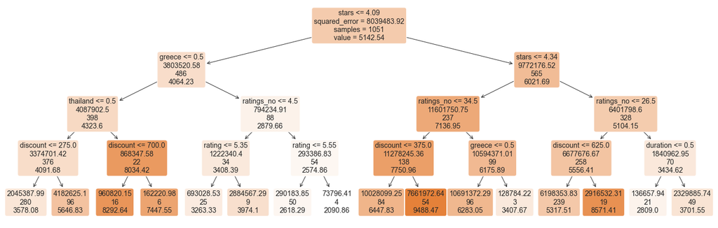

```python
tree = regressor.estimators_[123]
plt.figure(figsize=(25, 8))
plot_tree(tree,
          feature_names=X_test.columns,
          filled=True,
          rounded=True,
          fontsize=14,
          label='root',
          precision=2)
plt.show()
```

### Istotność zmiennych

Poniższy wykres przedstawia jak istotne okazały się być poszczególne zmienne podczas procesu decyzyjnego modelu. Największy udział przypadł zmiennej "Wysokość zniżki". Oznacza to, że informacja o tym jak bardzo przeceniona była wycieczka była jedną kluczowych dla modelu podczas prognozowania aktualnej ceny wycieczki. Innymi, stosunkowo ważnymi predyktorami cen wycieczek okazały się ilość gwiazdek przyznana od agencji oraz lotnisko, z którego rozpoczyna się wyjazd.

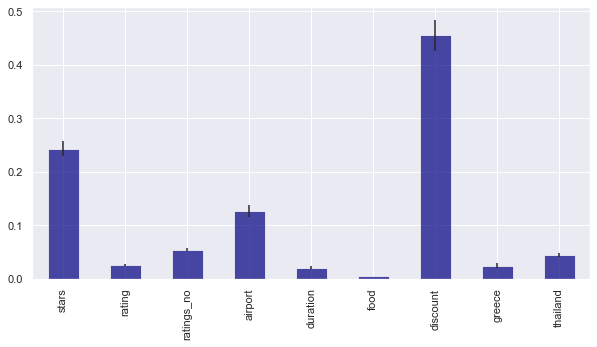

```python
feature_names = X_test.columns
importances = regressor.feature_importances_
forest_importances = pd.Series(importances, index=X_test.columns)
result = permutation_importance(regressor, X_test, y_test, n_repeats=10, random_state=seed)
rf_importances = pd.Series(result.importances_mean, index=feature_names)
fig, ax = plt.subplots(figsize=(10, 5))
forest_importances.plot.bar(yerr=result.importances_std, ax=ax, color='navy', alpha=0.7)
plt.show()
```

# Podsumowanie